# Capitulo_6_Componentes_Principales

Autor/a

Econometría para la Gestión (ECO_EPG) - FEN UAH

# 1 1. Material descargable

Descargar PDF de contenidos teóricos

e acuerdo al PDF teórico, el **Análisis de Componentes Principales (PCA)** es un método estadístico que:

- Busca **simplificar la complejidad** de un espacio de muchas variables (dimensiones) conservando la mayor parte posible de la información.
- Supone que tenemos $n$ individuos y $p$ variables $(X_1, \dots, X_p)$.
- Intenta encontrar un número menor de factores subyacentes $z < p$ (las **componentes principales**) que expliquen aproximadamente lo mismo que las $p$ variables originales.
- Pertenece a los métodos de **aprendizaje no supervisado (unsupervised learning)**: no hay una variable respuesta, sólo queremos entender la estructura interna de las variables explicativas.

Intuitivamente, el PCA:

- Busca la **dirección de máxima variabilidad** de los datos (primera componente).
- Luego busca una segunda dirección ortogonal a la primera que explique la máxima varianza restante, y así sucesivamente.
- Permite mirar los datos tanto desde el punto de vista de los **individuos** (observaciones) como de las **variables** (cómo se relacionan entre sí).

## 1.1 Normalización y matriz de correlación

Cuando las variables están en diferentes unidades, el primer paso es **normalizar** cada variable:

$$y_{ik} = \frac{x_{ik} - \bar x_k}{s_k}$$

donde $\bar x_k$ es la media de la variable $X_k$ y $s_k$ su desviación estándar.

De esta matriz calculamos sus **valores propios** ($\lambda_i$) y **vectores propios**, que corresponden a:

- Los **ejes preferenciales de información** (direcciones en las que hay más varianza).
- La proporción de varianza explicada por cada componente:

$$\text{contribución}_i = \frac{\lambda_i}{\sum_j \lambda_j}$$

# 2 Configuración inicial en R

## 2.1 Carga de librerías

En este laboratorio usaremos algunas librerías para facilitar el análisis:

```r
library(tidyverse)           # Manipulación de datos
library(psych)               # KMO, Bartlett, análisis psicométrico
library(corrplot)            # Gráficos de matrices de correlación
library(PerformanceAnalytics)# chart.Correlation
```

## 2.2 Ruta de trabajo (opcional)

Mantenemos la misma lógica de ruta de datos que en los laboratorios anteriores de ECO_EPG:

```r
ruta_datos <- "C:/Users/manue/Desktop/lab-econometria/labs_epg/data_epg"

# Puedes revisar el contenido de la carpeta
list.files(ruta_datos)
```

```
 [1] "annos_mantenimiento.xlsx" "auto_peso_consumo.xlsx"
 [3] "costos.xlsx"              "data_PCA_Decathlon.csv"
 [5] "data_PCA_ExpertWine.csv"  "Ejemplo1.xlsx"
 [7] "Ejemplo2.xlsx"            "millaje.txt"
 [9] "orange.csv"               "tabla_ejemplo_R.xlsx"
```

En este laboratorio usaremos principalmente **datasets incluidos en R**, de manera que puedas ejecutar el código incluso si no has descargado archivos adicionales.

# 3 Ejemplo 1: PCA con datos de autos (`mtcars`)

En este primer ejemplo aplicaremos PCA al dataset `mtcars` (incluido en R), que contiene información de distintos modelos de autos:

- `mpg`: millas por galón (consumo).
- `hp`: caballos de fuerza.
- `wt`: peso del auto.
- `qsec`: tiempo en 1/4 de milla.
- Entre otras variables.

La idea es **resumir** varias características técnicas de los autos en unas pocas **componentes principales**.

## 3.1 Selección y exploración de variables

```r
data(mtcars)

# Seleccionamos algunas variables numéricas de interés
datos_auto <- mtcars %>%
  select(mpg, hp, wt, qsec, disp, drat)

summary(datos_auto)
```

```
      mpg              hp              wt             qsec
 Min.   :10.40   Min.   : 52.0   Min.   :1.513   Min.   :14.50
 1st Qu.:15.43   1st Qu.: 96.5   1st Qu.:2.581   1st Qu.:16.89
 Median :19.20   Median :123.0   Median :3.325   Median :17.71
 Mean   :20.09   Mean   :146.7   Mean   :3.217   Mean   :17.85
 3rd Qu.:22.80   3rd Qu.:180.0   3rd Qu.:3.610   3rd Qu.:18.90
 Max.   :33.90   Max.   :335.0   Max.   :5.424   Max.   :22.90
      disp            drat
 Min.   : 71.1   Min.   :2.760
 1st Qu.:120.8   1st Qu.:3.080
 Median :196.3   Median :3.695
 Mean   :230.7   Mean   :3.597
 3rd Qu.:326.0   3rd Qu.:3.920
 Max.   :472.0   Max.   :4.930
```

**Tip**

Siempre es importante ver el **rango** y la **escala** de las variables:

- `mpg` está en millas por galón.
- `hp` en caballos de fuerza.
- `wt` en miles de libras.
- `qsec` en segundos.

Si no normalizamos, las variables con mayor escala dominarán el análisis.

## 3.2 Matriz de correlación

Antes de hacer PCA miramos la relación entre variables:

```r
cor_auto <- cor(datos_auto)
round(cor_auto, 2)
```

```
       mpg    hp    wt  qsec  disp  drat
mpg   1.00 -0.78 -0.87  0.42 -0.85  0.68
hp   -0.78  1.00  0.66 -0.71  0.79 -0.45
wt   -0.87  0.66  1.00 -0.17  0.89 -0.71
qsec  0.42 -0.71 -0.17  1.00 -0.43  0.09
disp -0.85  0.79  0.89 -0.43  1.00 -0.71
drat  0.68 -0.45 -0.71  0.09 -0.71  1.00
```

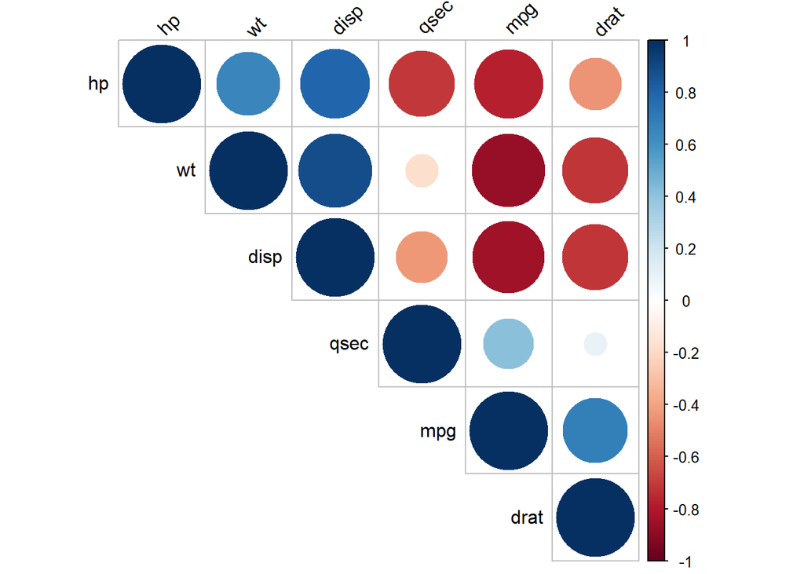

```r
corrplot(cor_auto,
         type  = "upper",
         order = "hclust",
         tl.col = "black",
         tl.srt = 45)
```

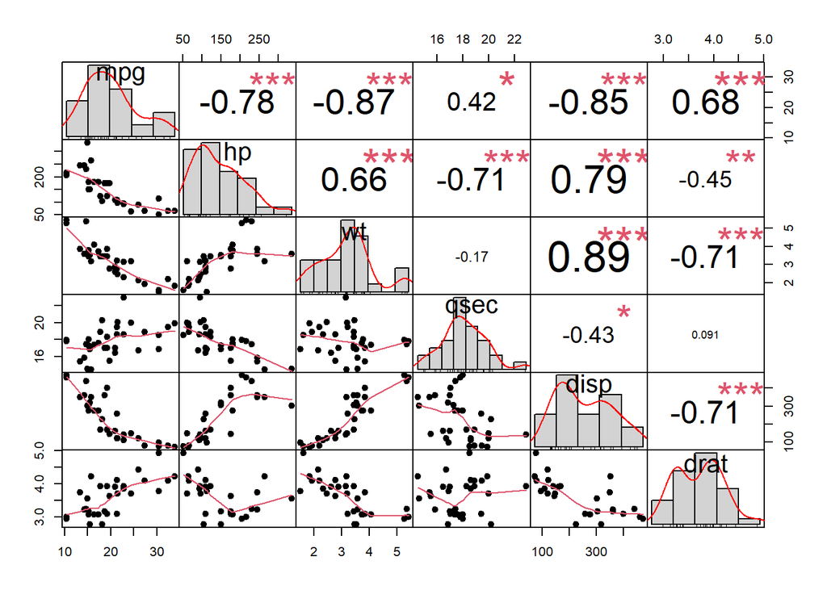

```r
chart.Correlation(datos_auto,
                  histogram = TRUE,
                  pch       = 19)
```

## 3.3 Test de Bartlett y KMO

Aplicamos los tests que se mencionan en el PDF teórico:

- **Bartlett**: contrasta si la matriz de correlación es esférica.
- **KMO**: evalúa la adecuación del muestreo para análisis factorial/PCA.

```r
psych::cortest.bartlett(cor_auto, n = nrow(datos_auto))
```

```
$chisq
[1] 181.2473

$p.value
[1] 1.332068e-30

$df
[1] 15
```

```r
KMO(cor_auto)
```

```
Kaiser-Meyer-Olkin factor adequacy
Call: KMO(r = cor_auto)
Overall MSA =  0.76
MSA for each item =
 mpg   hp   wt qsec disp drat
0.83 0.83 0.70 0.52 0.78 0.85
```

**Nota**

- Si el **p-value** de Bartlett es pequeño, la matriz de correlación es **distinta** de la identidad, lo que favorece el uso de PCA.
- Un **KMO** cercano a 1 indica que las variables comparten suficiente varianza común como para aplicar análisis factorial o PCA.

## 3.4 Normalización de las variables

Normalizamos las variables para que todas queden en escala comparable:

```r
datos_auto_norm <- scale(datos_auto)

head(datos_auto_norm)
```

```
                         mpg         hp           wt       qsec        disp
Mazda RX4          0.1508848 -0.5350928 -0.610399567 -0.7771651 -0.57061982
Mazda RX4 Wag      0.1508848 -0.5350928 -0.349785269 -0.4637808 -0.57061982
Datsun 710         0.4495434 -0.7830405 -0.917004624  0.4260068 -0.99018209
Hornet 4 Drive     0.2172534 -0.5350928 -0.002299538  0.8904872  0.22009369
Hornet Sportabout -0.2307345  0.4129422  0.227654255 -0.4637808  1.04308123
Valiant           -0.3302874 -0.6080186  0.248094592  1.3269868 -0.04616698
                        drat
Mazda RX4          0.5675137
Mazda RX4 Wag      0.5675137
Datsun 710         0.4739996
Hornet 4 Drive    -0.9661175
Hornet Sportabout -0.8351978
Valiant           -1.5646078
```

## 3.5 PCA con `prcomp`

Usamos la función base `prcomp`, que trabaja sobre la matriz de datos:

```r
pca_auto <- prcomp(datos_auto,
                   center = TRUE,  # restar la media
                   scale. = TRUE)  # dividir por la desviación estándar

summary(pca_auto)
```

```
Importance of components:
                          PC1    PC2     PC3     PC4    PC5     PC6
Standard deviation     2.0463 1.0715 0.57737 0.39289 0.3533 0.22799
Proportion of Variance 0.6979 0.1913 0.05556 0.02573 0.0208 0.00866
Cumulative Proportion  0.6979 0.8892 0.94481 0.97054 0.9913 1.00000
```

El `summary` muestra:

- La **desviación estándar** de cada componente.
- La **proporción de varianza** explicada por cada componente.
- La **varianza acumulada** (muy útil para decidir cuántas componentes retener).

## 3.6 Valores propios y varianza explicada

Los **valores propios** se obtienen elevando al cuadrado las desviaciones estándar de las componentes:

```r
eigenvalues <- pca_auto$sdev^2
eigenvalues
```

```
[1] 4.18739648 1.14811212 0.33335666 0.15436054 0.12479601 0.05197818
```

```r
prop_var <- eigenvalues / sum(eigenvalues)
prop_var
```

```
[1] 0.697899413 0.191352020 0.055559444 0.025726757 0.020799335 0.008663031
```

```r
acum_var <- cumsum(prop_var)
acum_var
```

```
[1] 0.6978994 0.8892514 0.9448109 0.9705376 0.9913370 1.0000000
```

### 3.6.1 Gráfico de sedimentación (scree plot)

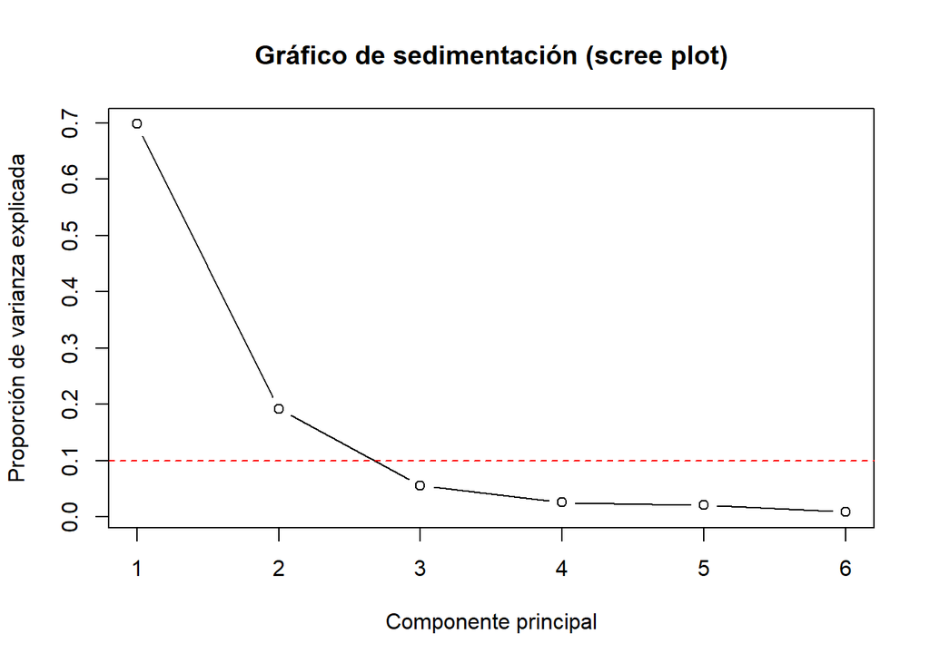

```r
plot(prop_var,
     type = "b",
     xlab = "Componente principal",
     ylab = "Proporción de varianza explicada",
     main = "Gráfico de sedimentación (scree plot)")

abline(h = 0.1, lty = 2, col = "red")
```

**Tip**

Ideas típicas para decidir el número de componentes:

- Mantener las componentes que explican en conjunto, por ejemplo, **70%-80%** de la varianza.
- Detenerse cuando el scree plot muestra un **“codo”** evidente.
- Mantener sólo las componentes con valor propio mayor que 1 (criterio de Kaiser) cuando se trabaja sobre matriz de correlación.

## 3.7 Cargas (loadings) e interpretación

```r
pca_auto$rotation
```

```
            PC1         PC2         PC3         PC4        PC5         PC6
mpg  -0.4586835 -0.05867609 -0.19479235 -0.78205878  0.1111533  0.35249327
hp    0.4258534 -0.36147576  0.14613554 -0.12301873  0.8057408  0.04771555
wt    0.4386179  0.29953457  0.41776208 -0.10438337 -0.2301541  0.69246040
qsec -0.2528320  0.76284877  0.34059066 -0.04268124  0.4218755 -0.24152663
disp  0.4660354  0.06065296  0.09688406 -0.60001871 -0.2946297 -0.56825752
drat -0.3670963 -0.43652537  0.80049152 -0.02259258 -0.1437714 -0.11277675
```

- Valores altos (en valor absoluto) indican que la variable tiene una gran influencia en esa componente.
- El **signo** indica dirección de la relación (positiva o negativa).

## 3.8 Coordenadas de los individuos (scores)

```r
head(pca_auto$x)
```

```
                         PC1          PC2        PC3        PC4         PC5
Mazda RX4         -0.8425806 -0.873469391 -0.2282783  0.3742725 -0.51522641
Mazda RX4 Wag     -0.8075041 -0.556341552 -0.0126678  0.3336931 -0.44299870
Datsun 710        -1.6850448  0.040006569 -0.1564937  0.4057157  0.03340433
Hornet 4 Drive    -0.0964443  1.294377904 -0.5702297 -0.2520788  0.04326023
Hornet Sportabout  1.2915096  0.006516693 -0.5250741 -0.4813192 -0.12822104
Valiant            0.2187309  2.005957905 -0.7258399  0.3136170  0.21465335
                          PC6
Mazda RX4          0.05293884
Mazda RX4 Wag      0.15771326
Datsun 710        -0.10756126
Hornet 4 Drive    -0.18173489
Hornet Sportabout -0.29051949
Valiant           -0.09145688
```

Cada fila corresponde a un auto, y cada columna a su coordenada en una componente principal (por ejemplo, PC1, PC2).

## 3.9 Biplot: individuos y variables

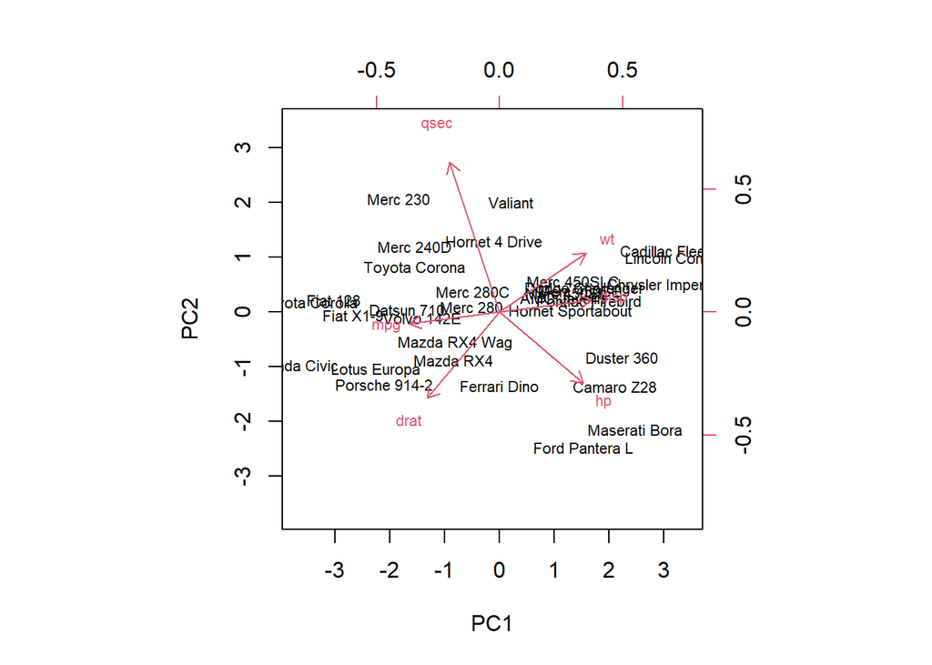

```r
biplot(pca_auto,
       scale = 0,
       cex   = 0.7)
```

**Nota**

- Los **puntos** son los autos (individuos).
- Las **flechas** representan las variables originales.
- La dirección y longitud de cada flecha muestran cómo cada variable contribuye a las primeras componentes.

# 4 Ejemplo 2: PCA con datos simulados de indicadores regionales

Ahora construiremos un segundo ejemplo, inventando un conjunto de datos que se parezca a una situación típica en economía o gestión: indicadores para distintas **regiones**.

Supongamos que medimos para cada región:

- `ingreso_pc`: ingreso per cápita.
- `desempleo`: tasa de desempleo.
- `escolaridad`: años promedio de estudio.
- `pobreza`: porcentaje de población bajo la línea de pobreza.
- `gini`: índice de desigualdad (0–1).

La idea es usar PCA para encontrar **patrones conjuntos** entre estos indicadores.

## 4.1 Creación de datos simulados

```r
set.seed(123)

n_regiones <- 16

datos_regiones <- tibble(
  region      = paste("Region", 1:n_regiones),
  ingreso_pc  = round(rnorm(n_regiones, mean = 800000, sd = 150000)),
  desempleo   = round(rnorm(n_regiones, mean = 8, sd = 2), 1),
  escolaridad = round(rnorm(n_regiones, mean = 11, sd = 1.5), 1),
  pobreza     = round(rnorm(n_regiones, mean = 15, sd = 5), 1),
  gini        = round(rnorm(n_regiones, mean = 0.45, sd = 0.05), 2)
)

datos_regiones
```

```
# A tibble: 16 × 6
   region    ingreso_pc desempleo escolaridad pobreza  gini
   <chr>          <dbl>     <dbl>       <dbl>   <dbl> <dbl>
 1 Region 1      715929       9          12.3    18.9  0.4
 2 Region 2      765473       4.1        12.3    14.6  0.47
 3 Region 3     1033806       9.4        12.2    16.3  0.47
 4 Region 4      810576       7.1        12      14.9  0.45
 5 Region 5      819393       5.9        11.8    14.8  0.5
 6 Region 6     1057260       7.6        10.9    21.8  0.55
 7 Region 7      869137       5.9        10.5    13.9  0.43
 8 Region 8      610241       6.5        10.4    22.6  0.33
 9 Region 9      696972       6.7        10       7.3  0.5
10 Region 10     733151       4.6        10.7    17.9  0.41
11 Region 11     983612       9.7         9.1    15.6  0.42
12 Region 12     853972       8.3        14.3    16.1  0.5
13 Region 13     860116       5.7        12.8    16.9  0.44
14 Region 14     816602      10.5         9.3    12.5  0.39
15 Region 15     716624       8.9        10.4    13.3  0.46
16 Region 16    1068037       7.4        10.3     9.9  0.44
```

## 4.2 Exploración inicial

```r
summary(select(datos_regiones, -region))
```

```
   ingreso_pc        desempleo       escolaridad       pobreza
 Min.   : 610241   Min.   : 4.100   Min.   : 9.10   Min.   : 7.30
 1st Qu.: 729019   1st Qu.: 5.900   1st Qu.:10.38   1st Qu.:13.75
 Median : 817998   Median : 7.250   Median :10.80   Median :15.25
 Mean   : 838181   Mean   : 7.331   Mean   :11.21   Mean   :15.46
 3rd Qu.: 897756   3rd Qu.: 8.925   3rd Qu.:12.22   3rd Qu.:17.15
 Max.   :1068037   Max.   :10.500   Max.   :14.30   Max.   :22.60
      gini
 Min.   :0.3300
 1st Qu.:0.4175
 Median :0.4450
 Mean   :0.4475
 3rd Qu.:0.4775
 Max.   :0.5500
```

## 4.3 Matriz de correlación

```r
vars_reg <- select(datos_regiones, -region)
cor_reg  <- cor(vars_reg)
round(cor_reg, 2)
```

```
            ingreso_pc desempleo escolaridad pobreza  gini
ingreso_pc        1.00      0.30       -0.01   -0.06  0.44
desempleo         0.30      1.00       -0.23   -0.06 -0.09
escolaridad      -0.01     -0.23        1.00    0.26  0.34
pobreza          -0.06     -0.06        0.26    1.00 -0.22
gini              0.44     -0.09        0.34   -0.22  1.00
```

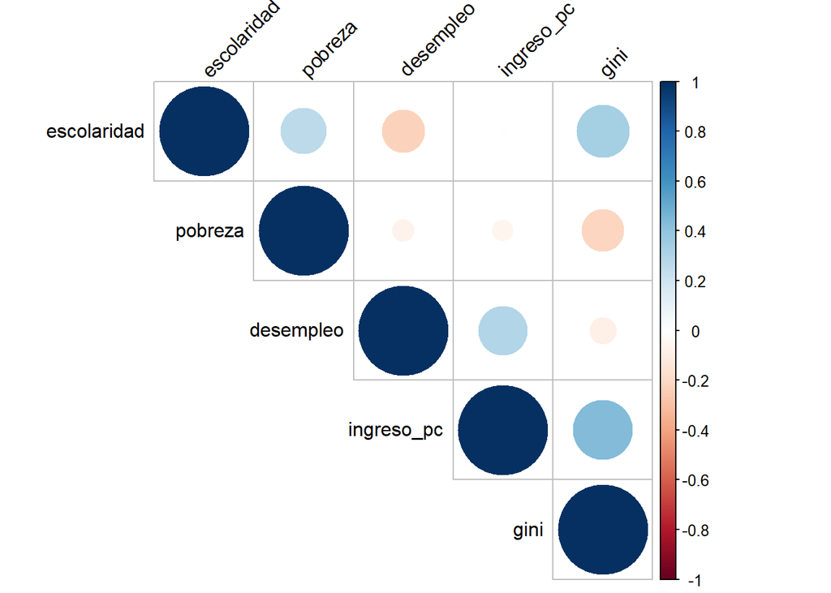

```r
corrplot(cor_reg,
         type  = "upper",
         order = "hclust",
         tl.col = "black",
         tl.srt = 45)
```

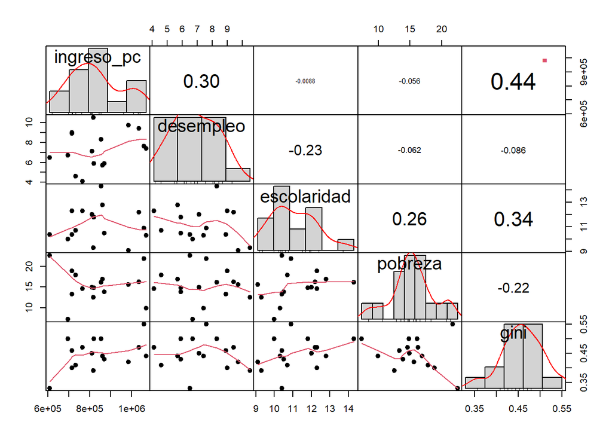

```r
chart.Correlation(vars_reg, histogram = TRUE, pch = 19)
```

## 4.4 Bartlett y KMO

```r
psych::cortest.bartlett(cor_reg, n = nrow(datos_regiones))
```

```
$chisq
[1] 9.531286

$p.value
[1] 0.4825305

$df
[1] 10
```

```r
KMO(cor_reg)
```

```
Kaiser-Meyer-Olkin factor adequacy
Call: KMO(r = cor_reg)
Overall MSA =  0.38
MSA for each item =
 ingreso_pc   desempleo escolaridad     pobreza        gini
       0.40        0.46        0.39        0.30        0.38
```

## 4.5 PCA sobre indicadores regionales

```r
pca_reg <- prcomp(vars_reg,
                  center = TRUE,
                  scale. = TRUE)

summary(pca_reg)
```

```
Importance of components:
                          PC1    PC2    PC3    PC4     PC5
Standard deviation     1.2525 1.2071 1.0262 0.7718 0.57039
Proportion of Variance 0.3138 0.2914 0.2106 0.1191 0.06507
Cumulative Proportion  0.3138 0.6052 0.8158 0.9349 1.00000
```

### 4.5.1 Varianza explicada

```r
eig_reg   <- pca_reg$sdev^2
prop_reg  <- eig_reg / sum(eig_reg)
acum_reg  <- cumsum(prop_reg)

prop_reg
```

```
[1] 0.31375635 0.29143673 0.21061115 0.11912759 0.06506818
```

```r
acum_reg
```

```
[1] 0.3137564 0.6051931 0.8158042 0.9349318 1.0000000
```

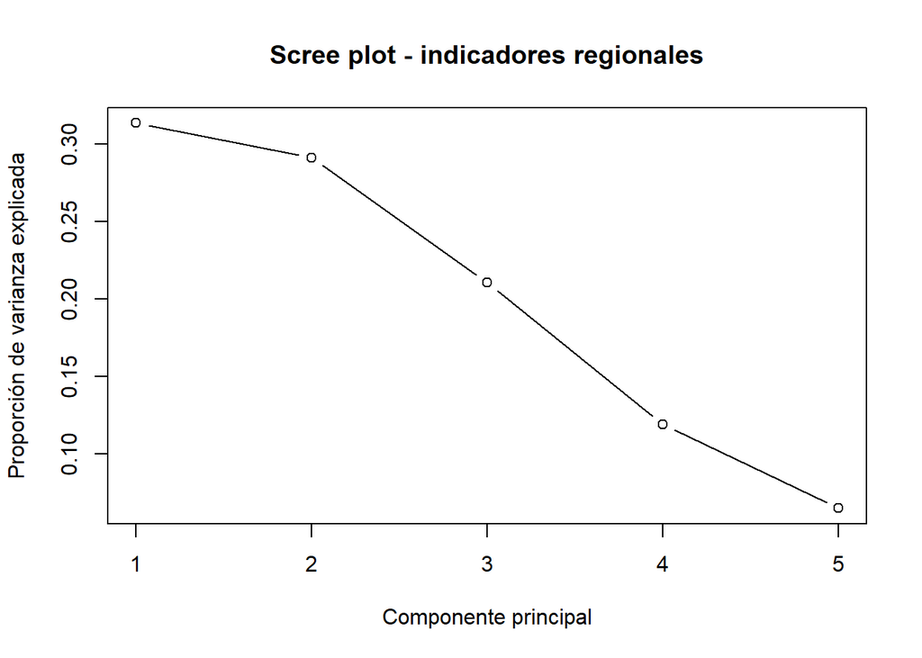

```r
plot(prop_reg,
     type = "b",
     xlab = "Componente principal",
     ylab = "Proporción de varianza explicada",
     main = "Scree plot - indicadores regionales")
```

## 4.6 Interpretación de las componentes

```r
pca_reg$rotation
```

```
                   PC1        PC2        PC3          PC4        PC5
ingreso_pc   0.6287024  0.2048168  0.3221309  0.471827456 -0.4862035
desempleo    0.1577429  0.5621811  0.5069584 -0.605120552  0.1894515
escolaridad  0.2260606 -0.6701855  0.1702061 -0.549672409 -0.4106557
pobreza     -0.2399983 -0.3756731  0.7540961  0.330237323  0.3515011
gini         0.6864021 -0.2274283 -0.2039456  0.003394633  0.6599418
```

## 4.7 Coordenadas de las regiones en el espacio de componentes

```r
scores_reg <- as_tibble(pca_reg$x) %>%
  mutate(region = datos_regiones$region)

scores_reg
```

```
# A tibble: 16 × 6
       PC1    PC2    PC3     PC4      PC5 region
     <dbl>  <dbl>  <dbl>   <dbl>    <dbl> <chr>
 1 -1.07   -0.335  1.15  -1.11   -0.00143 Region 1
 2 -0.0845 -1.63  -1.17   0.296  -0.190   Region 2
 3  1.47    0.260  1.22  -0.319  -0.420   Region 3
 4  0.0496 -0.451 -0.148 -0.381  -0.179   Region 4
 5  0.611  -0.909 -0.691  0.113   0.342   Region 5
 6  1.92   -0.497  1.39   1.33    1.19    Region 6
 7 -0.225   0.180 -0.638  0.718  -0.406   Region 7
 8 -3.21   -0.387  0.977  0.403   0.141   Region 8
 9  0.287   0.742 -2.44  -0.493   0.712   Region 9
10 -1.43   -0.812 -0.434  0.931  -0.00298 Region 10
11  0.160   2.05   0.863  0.575   0.0168  Region 11
12  1.30   -1.46   0.602 -1.43   -0.158   Region 12
13  0.0352 -1.34   0.111  0.0974 -0.678   Region 13
14 -0.705   2.38   0.227 -0.605  -0.0228  Region 14
15 -0.261   0.835 -0.424 -0.792   0.791   Region 15
16  1.16    1.37  -0.600  0.656  -1.14    Region 16
```

### 4.7.1 Gráfico de las regiones en PC1–PC2

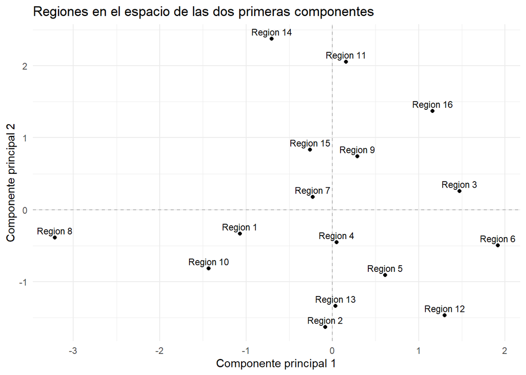

```r
ggplot(scores_reg, aes(x = PC1, y = PC2, label = region)) +
  geom_hline(yintercept = 0, linetype = "dashed", color = "grey70") +
  geom_vline(xintercept = 0, linetype = "dashed", color = "grey70") +
  geom_point() +
  geom_text(vjust = -0.5, size = 3) +
  labs(title = "Regiones en el espacio de las dos primeras componentes",
       x = "Componente principal 1",
       y = "Componente principal 2") +
  theme_minimal()
```

## 4.8 Biplot con variables e individuos

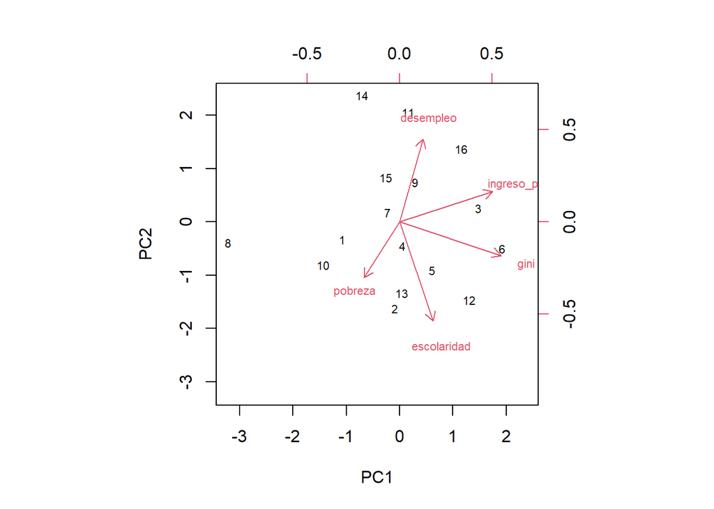

```r
biplot(pca_reg,
       scale = 0,
       cex   = 0.7)
```

# 5 Cierre del laboratorio

En este laboratorio trabajaste, apoyado en el PDF del **Capítulo 6: Componentes Principales**, los siguientes aspectos:

- La **motivación** del PCA como técnica de reducción de dimensión y exploración de datos multivariados.
- La importancia de **normalizar** las variables cuando están en distintas escalas.
- La construcción de la **matriz de correlaciones** y el uso de **Bartlett** y **KMO** para evaluar si el PCA (o análisis factorial) es razonable.
- El cálculo e interpretación de **valores propios**, **varianza explicada** y **scree plot**.
- La lectura de las **cargas (loadings)** de las variables y de las **coordenadas (scores)** de los individuos.
- La interpretación conjunta de individuos y variables a través de **biplots**.

Estos elementos son la base para aplicar PCA en contextos reales de economía y gestión, donde a menudo trabajamos con muchos indicadores simultáneamente y necesitamos **resumir la información** de forma clara y robusta.